# **Problem Statement**

## **Business Context**

Workplace safety in hazardous environments like construction sites and industrial plants is crucial to prevent accidents and injuries. One of the most important safety measures is ensuring workers wear safety helmets, which protect against head injuries from falling objects and machinery. Non-compliance with helmet regulations increases the risk of serious injuries or fatalities, making effective monitoring essential, especially in large-scale operations where manual oversight is prone to errors and inefficiency.

To overcome these challenges, SafeGuard Corp plans to develop an automated image analysis system capable of detecting whether workers are wearing safety helmets. This system will improve safety enforcement, ensuring compliance and reducing the risk of head injuries. By automating helmet monitoring, SafeGuard aims to enhance efficiency, scalability, and accuracy, ultimately fostering a safer work environment while minimizing human error in safety oversight.

## **Objective**

As a data scientist at SafeGuard Corp, you are tasked with developing an image classification model that classifies images into one of two categories:

- **With Helmet:** Workers wearing safety helmets.
- **Without Helmet:** Workers not wearing safety helmets.

## **Data Description**

The dataset consists of **631 images**, equally divided into two categories:

- **With Helmet:** 311 images showing workers wearing helmets.
- **Without Helmet:** 320 images showing workers not wearing helmets.

**Dataset Characteristics:**

- **Variations in Conditions:** Images include diverse environments such as construction sites, factories, and industrial settings, with variations in lighting, angles, and worker postures to simulate real-world conditions.
- **Worker Activities:** Workers are depicted in different actions such as standing, using tools, or moving, ensuring robust model learning for various scenarios.

# **Installing and Importing the Necessary Libraries**

```python
!pip install tensorflow[and-cuda] numpy==1.25.2 -q
```

[output not shown]

```python
import tensorflow as tf
print("Num GPUs Available:", len(tf.config.list_physical_devices('GPU')))
print(tf.__version__)
```

```
Num GPUs Available: 0
2.17.1
```

**Note:**

- After running the above cell, kindly restart the notebook kernel (for Jupyter Notebook) or runtime (for Google Colab) and run all cells sequentially from the next cell.
- On executing the above line of code, you might see a warning regarding package dependencies. This error message can be ignored as the above code ensures that all necessary libraries and their dependencies are maintained to successfully execute the code in this notebook.

```python
import os
import random
import numpy as np                                                                               # Importing numpy for Matrix Operations
import pandas as pd
import seaborn as sns
import matplotlib.image as mpimg                                                                              # Importing pandas to read CSV files
import matplotlib.pyplot as plt                                                                  # Importting matplotlib for Plotting and visualizing images
import math                                                                                      # Importing math module to perform mathematical operations
import cv2


# Tensorflow modules
import keras
import tensorflow as tf
from tensorflow.keras.preprocessing.image import ImageDataGenerator                              # Importing the ImageDataGenerator for data augmentation
from tensorflow.keras.models import Sequential                                                   # Importing the sequential module to define a sequential model
from tensorflow.keras.layers import Dense,Dropout,Flatten,Conv2D,MaxPooling2D,BatchNormalization # Defining all the layers to build our CNN Model
from tensorflow.keras.optimizers import Adam,SGD                                                 # Importing the optimizers which can be used in our model
from sklearn import preprocessing                                                                # Importing the preprocessing module to preprocess the data
from sklearn.model_selection import train_test_split                                             # Importing train_test_split function to split the data into train and test
from sklearn.metrics import confusion_matrix
from tensorflow.keras.models import Model
from keras.applications.vgg16 import VGG16                                               # Importing confusion_matrix to plot the confusion matrix

# Display images using OpenCV
from google.colab.patches import cv2_imshow

#Imports functions for evaluating the performance of machine learning models
from sklearn.metrics import confusion_matrix, f1_score,accuracy_score, recall_score, precision_score, classification_report
from sklearn.metrics import mean_squared_error as mse                                                 # Importing cv2_imshow from google.patches to display images

# Ignore warnings
import warnings
warnings.filterwarnings('ignore')
```

```python
# Set the seed using keras.utils.set_random_seed. This will set:
# 1) `numpy` seed
# 2) backend random seed
# 3) `python` random seed
tf.keras.utils.set_random_seed(812)
```

# **Data Overview**

## Loading the data

```python
# Uncomment and run the following code in case Google Colab is being used
from google.colab import drive
drive.mount('/content/drive')
```

```python
# Load the image file of the dataset
images = np.load('/content/drive/My Drive/PGP-AIML/Introduction to Computer Vision/Project : Introduction to Computer Vision : HelmNet/images_proj.npy')

# Load the labels file of the dataset
labels = pd.read_csv('/content/drive/My Drive/PGP-AIML/Introduction to Computer Vision/Project : Introduction to Computer Vision : HelmNet/Labels_proj.csv')
```

# **Data Overview**

Getting the Data Overview Here on the basis of Data Description to build Better understanding

```python
print(images.shape)
print(labels.shape)
```

```
(631, 200, 200, 3)
(631, 1)
```

```python
plt.imshow(images[5])
```

[output not shown]

# **Exploratory Data Analysis**

### Plot random images from each of the classes and print their corresponding labels.

```python
# Converting the images from BGR to RGB using cvtColor function of OpenCV
for i in range(len(images)):
  images[i] = cv2.cvtColor(images[i], cv2.COLOR_BGR2RGB)
```

```python
def plot_images(images,labels):
  num_classes=10                                                                  # Number of Classes
  categories=np.unique(labels)
  keys=dict(labels['Label'])                                                      # Obtaing the unique classes from y_train
  rows = 3                                                                        # Defining number of rows=3
  cols = 4                                                                        # Defining number of columns=4
  fig = plt.figure(figsize=(10, 8))                                               # Defining the figure size to 10x8
  for i in range(cols):
      for j in range(rows):
          random_index = np.random.randint(0, len(labels))                        # Generating random indices from the data and plotting the images
          ax = fig.add_subplot(rows, cols, i * rows + j + 1)                      # Adding subplots with 3 rows and 4 columns
          ax.imshow(images[random_index, :])                                      # Plotting the image
          ax.set_title(keys[random_index])
  plt.show()
```

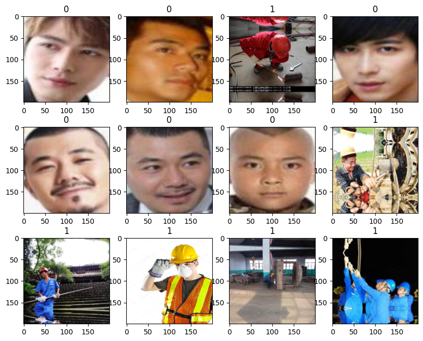

```python
plot_images(images,labels)
```

## Checking for class imbalance

[figure not shown]

```python
#creates a countplot. A countplot is a type of bar plot that shows the counts of
 #observations in each categorical bin using bars. In this case, it's counting the
 #occurrences of each unique value in the 'Label' column of your labels DataFrame.
 #This will visually represent how many images are in each category (likely "With Helmet" and "Without Helmet"),
 # helping you understand if the classes are balanced or imbalanced.
 sns.countplot(labels['Label'])
#Rotates the labels on the x-axis of the plot to be vertical.
#This is useful if the labels are long and would otherwise overlap.
#The semicolon at the end is used to suppress the output of the last expression in the cell,
#which would normally be a matplotlib text object.
 plt.xticks(rotation='vertical');
```

The Distribution of Data is uniform across DataSet

# **Data Preprocessing**

This section focuses on preparing the image data for training machine learning models. Preprocessing is an essential step in computer vision projects [1], and its goal here is to make the data suitable and efficient for model training.

The preprocessing steps performed in this section are:

Resizing Images: The images are resized to a smaller dimension. This is done to reduce the computational resources required for training models and to speed up the training process. Smaller images mean less data for the model to process.

Splitting the Dataset: The dataset is divided into three subsets: a training set, a validation set, and a test set. The training set is used to train the model. The validation set is used to evaluate the model's performance during training and to tune hyperparameters. The test set is used for a final, unbiased evaluation of the trained model's performance on unseen data.

## Resizing Image

```python
images_decreased = []
height = 64
width = 64
dimensions = (width, height)
for i in range(len(images)):
  images_decreased.append( cv2.resize(images[i], dimensions, interpolation=cv2.INTER_LINEAR))
```

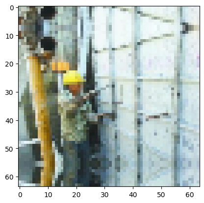

```python
plt.imshow(images_decreased[3]);
```

## Converting images to grayscale

```python
images_gray = []
for i in range(len(images_decreased)):
    gray = cv2.cvtColor(images_decreased[i], cv2.COLOR_RGB2GRAY)  # Use COLOR_BGR2GRAY if the input is in BGR
    images_gray.append(gray)
```

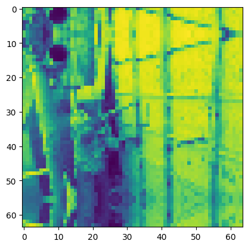

```python
plt.imshow(images_gray[3]);
```

### Splitting the dataset

```python
X_train, X_temp, y_train, y_temp = train_test_split(np.array(images_decreased),labels , test_size=0.2, random_state=42,stratify=labels)
X_val, X_test, y_val, y_test = train_test_split(X_temp,y_temp , test_size=0.5, random_state=42,stratify=y_temp)
```

```python
print(X_train.shape,y_train.shape)
print(X_val.shape,y_val.shape)
print(X_test.shape,y_test.shape)
```

```
(504, 64, 64, 3) (504, 1)
(63, 64, 64, 3) (63, 1)
(64, 64, 64, 3) (64, 1)
```

```python
# Convert labels from names to one hot vectors.
# We have already used encoding methods like onehotencoder and labelencoder earlier so now we will be using a new encoding method called labelBinarizer.
# Labelbinarizer works similar to onehotencoder

from sklearn.preprocessing import LabelBinarizer
enc = LabelBinarizer()
y_train_encoded = enc.fit_transform(y_train)
y_val_encoded=enc.transform(y_val)
y_test_encoded=enc.transform(y_test)
```

### Data Normalization

```python
# Normalizing the image pixels
X_train_normalized = X_train.astype('float32')/255.0 # Convert training images to float32 and normalize pixel values
X_val_normalized = X_val.astype('float32')/255.0     # Convert validation images to float32 and normalize pixel values
X_test_normalized = X_test.astype('float32')/255.0   # Convert test images to float32 and normalize pixel values
```

# **Model Building**

## Model Evaluation Criterion

## Utility Functions

```python
# defining a function to compute different metrics to check performance of a classification model built using statsmodels
def model_performance_classification(model, predictors, target):
    """
    Function to compute different metrics to check classification model performance

    model: classifier
    predictors: independent variables
    target: dependent variable
    """

    # checking which probabilities are greater than threshold
    pred = model.predict(predictors).reshape(-1)>0.5

    # target = target.to_numpy().reshape(-1) # Remove .to_numpy() as target can be a numpy array

    # Ensure target is a numpy array and reshaped if needed
    if hasattr(target, 'to_numpy'):
        target = target.to_numpy().reshape(-1)
    else:
        target = target.reshape(-1)


    acc = accuracy_score(target, pred)  # to compute Accuracy
    recall = recall_score(target, pred, average='weighted')  # to compute Recall
    precision = precision_score(target, pred, average='weighted')  # to compute Precision
    f1 = f1_score(target, pred, average='weighted')  # to compute F1-score

    # creating a dataframe of metrics
    df_perf = pd.DataFrame({"Accuracy": acc, "Recall": recall, "Precision": precision, "F1 Score": f1,},index=[0],)

    return df_perf
```

```python
def plot_confusion_matrix(model,predictors,target,ml=False):
    """
    Function to plot the confusion matrix

    model: classifier
    predictors: independent variables
    target: dependent variable
    ml: To specify if the model used is an sklearn ML model or not (True means ML model)
    """

    # checking which probabilities are greater than threshold
    pred = model.predict(predictors).reshape(-1)>0.5

    #target = target.to_numpy().reshape(-1) # Original line that caused the error

    # Check if target is a pandas Series or DataFrame and convert to numpy if necessary
    if hasattr(target, 'to_numpy'):
        target = target.to_numpy().reshape(-1)
    else:
        # Assume target is already a numpy array and reshape if needed
        target = target.reshape(-1)


    # Plotting the Confusion Matrix using confusion matrix() function which is also predefined tensorflow module
    confusion_matrix = tf.math.confusion_matrix(target,pred)
    f, ax = plt.subplots(figsize=(10, 8))
    sns.heatmap(
        confusion_matrix,
        annot=True,
        linewidths=.4,
        fmt="d",
        square=True,
        ax=ax
    )
    plt.show()
```

## Model 1: Simple Convolutional Neural Network (CNN)

This code defines and compiles a simple Convolutional Neural Network (CNN) for image classification. It starts by clearing the Keras backend and setting random seeds for reproducibility. The model is a sequential stack of layers, including Conv2D layers for feature extraction, MaxPooling2D layers for downsampling, a Flatten layer to prepare data for dense layers, and two Dense layers. The output layer uses a sigmoid activation for binary classification. The model is compiled using the Adam optimizer, binary cross-entropy loss, and accuracy as the evaluation metric. Finally, a summary of the model's architecture is printed.

```python
# Clearing backend
from tensorflow.keras import backend
backend.clear_session()

# Fixing the seed for random number generators
import random
import numpy as np
import tensorflow as tf
np.random.seed(42)
random.seed(42)
tf.random.set_seed(42)

# Intializing a sequential model
model_1 = Sequential()

# Adding first conv layer with 64 filters and kernel size 3x3 , padding 'same' provides the output size same as the input size
# Update input_shape to match the training data dimensions (64x64 with 3 channels)
model_1.add(Conv2D(64, (3, 3), activation='relu', padding="same", input_shape=(64, 64, 3)))

# Adding max pooling to reduce the size of output of first conv layer
model_1.add(MaxPooling2D((2, 2), padding = 'same'))

model_1.add(Conv2D(32, (3, 3), activation='relu', padding="same"))
model_1.add(MaxPooling2D((2, 2), padding = 'same'))
model_1.add(Conv2D(32, (3, 3), activation='relu', padding="same"))
model_1.add(MaxPooling2D((2, 2), padding = 'same'))

# flattening the output of the conv layer after max pooling to make it ready for creating dense connections
model_1.add(Flatten())

# Adding a fully connected dense layer with 100 neurons
model_1.add(Dense(100, activation='relu'))

# Adding the output layer
# For binary classification, the output layer should have 1 neuron with 'sigmoid' activation
model_1.add(Dense(1, activation='sigmoid'))

# Using Adam Optimizer (often better than SGD for CNNs)
from tensorflow.keras.optimizers import Adam
opt = Adam()

# Compile model
# For binary classification, the loss should be 'binary_crossentropy'
model_1.compile(optimizer=opt, loss='binary_crossentropy', metrics=['accuracy'])

# Generating the summary of the model
model_1.summary()
```

```
Model: "sequential"
```

```
┏━━━━━━━━━━━━━━━━━━━━━━━━━━━━━━━━━┳━━━━━━━━━━━━━━━━━━━━━━━━┳━━━━━━━━━━━━━━━┓
┃ Layer (type)                    ┃ Output Shape           ┃       Param # ┃
┡━━━━━━━━━━━━━━━━━━━━━━━━━━━━━━━━━╇━━━━━━━━━━━━━━━━━━━━━━━━╇━━━━━━━━━━━━━━━┩
│ conv2d (Conv2D)                 │ (None, 64, 64, 64)     │         1,792 │
├─────────────────────────────────┼────────────────────────┼───────────────┤
│ max_pooling2d (MaxPooling2D)    │ (None, 32, 32, 64)     │             0 │
├─────────────────────────────────┼────────────────────────┼───────────────┤
│ conv2d_1 (Conv2D)               │ (None, 32, 32, 32)     │        18,464 │
├─────────────────────────────────┼────────────────────────┼───────────────┤
│ max_pooling2d_1 (MaxPooling2D)  │ (None, 16, 16, 32)     │             0 │
├─────────────────────────────────┼────────────────────────┼───────────────┤
│ conv2d_2 (Conv2D)               │ (None, 16, 16, 32)     │         9,248 │
├─────────────────────────────────┼────────────────────────┼───────────────┤
│ max_pooling2d_2 (MaxPooling2D)  │ (None, 8, 8, 32)       │             0 │
├─────────────────────────────────┼────────────────────────┼───────────────┤
│ flatten (Flatten)               │ (None, 2048)           │             0 │
├─────────────────────────────────┼────────────────────────┼───────────────┤
│ dense (Dense)                   │ (None, 100)            │       204,900 │
├─────────────────────────────────┼────────────────────────┼───────────────┤
│ dense_1 (Dense)                 │ (None, 1)              │           101 │
└─────────────────────────────────┴────────────────────────┴───────────────┘
```

```
 Total params: 234,505 (916.04 KB)
```

```
 Trainable params: 234,505 (916.04 KB)
```

```
 Non-trainable params: 0 (0.00 B)
```

This code snippet sets up and trains a Convolutional Neural Network (model_1) for image classification. It begins by importing EarlyStopping, a callback that monitors a metric (here, validation loss) during training and stops if it doesn't improve for a set number of epochs (patience=5), preventing overfitting. It also saves the model's best weights found during training.

The model is then compiled with the Adam optimizer, using 'categorical_crossentropy' as the loss function suitable for multi-class problems with one-hot encoded labels, and tracking 'accuracy'.

Finally, model_1.fit() starts the training process. It uses the normalized training data (X_train_normalized, y_train_encoded) and evaluates performance on the validation data (validation_data). It trains for a maximum of 50 epochs, processing data in batches of 32. The callbacks list includes the configured EarlyStopping, which will halt training early if validation loss plateaus. The training progress is stored in history_1.

```python
from tensorflow.keras.callbacks import EarlyStopping # Import EarlyStopping callback

callbacks = [
    EarlyStopping(monitor='val_loss', patience=5, restore_best_weights=True)
]
model_1.compile(
    loss='categorical_crossentropy',
    optimizer=tf.keras.optimizers.Adam(learning_rate=0.001),
    metrics=['accuracy']
)

history_1 = model_1.fit(
    X_train_normalized, y_train_encoded,
    validation_data=(X_val_normalized, y_val_encoded),
    epochs=50,
    batch_size=32,
    callbacks=callbacks
)
```

```
16/16 ━━━━━━━━━━━━━━━━━━━━ 10s 316ms/step - accuracy: 0.6392 - loss: 0.0000e+00 - val_accuracy: 0.5079 - val_loss: 0.0000e+00
16/16 ━━━━━━━━━━━━━━━━━━━━ 4s 261ms/step - accuracy: 0.5127 - loss: 0.0000e+00 - val_accuracy: 0.5079 - val_loss: 0.0000e+00
16/16 ━━━━━━━━━━━━━━━━━━━━ 7s 390ms/step - accuracy: 0.5127 - loss: 0.0000e+00 - val_accuracy: 0.5079 - val_loss: 0.0000e+00
16/16 ━━━━━━━━━━━━━━━━━━━━ 4s 250ms/step - accuracy: 0.5127 - loss: 0.0000e+00 - val_accuracy: 0.5079 - val_loss: 0.0000e+00
16/16 ━━━━━━━━━━━━━━━━━━━━ 4s 250ms/step - accuracy: 0.5127 - loss: 0.0000e+00 - val_accuracy: 0.5079 - val_loss: 0.0000e+00
16/16 ━━━━━━━━━━━━━━━━━━━━ 7s 372ms/step - accuracy: 0.5127 - loss: 0.0000e+00 - val_accuracy: 0.5079 - val_loss: 0.0000e+00
```

This code visualizes the performance of a trained image classification model over time. It plots two lines on a graph: one showing the model's accuracy on the training data (Train) and the other showing its accuracy on separate validation data (Validation) after each training epoch. This helps in understanding if the model is learning effectively or if there's a difference in performance between the data it trained on and unseen data, which could indicate overfitting or underfitting. The labels and title make the plot easy to interpret.

[figure not shown]

```python
plt.plot(history_1.history['accuracy'])
plt.plot(history_1.history['val_accuracy'])
plt.title('Model Accuracy')
plt.ylabel('Accuracy')
plt.xlabel('Epoch')
plt.legend(['Train', 'Validation'], loc='upper left')
plt.show()
```

This code evaluates a trained image classification model (model_1) using utility functions. It calls model_performance_classification with the model and normalized training data and labels to compute key metrics like Accuracy, Recall, Precision, and F1 Score. These metrics are stored in a variable model_1_train_perf. Finally, it prints the header "Train performance metrics" and then displays the computed metrics in the model_1_train_perf variable. This helps assess how well the model performed on the data it was trained on.

```python
model_1_train_perf = model_performance_classification(model_1, X_train_normalized,y_train_encoded)

print("Train performance metrics")
print(model_1_train_perf)
```

[output not shown]

This line of code calls the user-defined function plot_confusion_matrix.

```
16/16 ━━━━━━━━━━━━━━━━━━━━ 1s 62ms/step
```

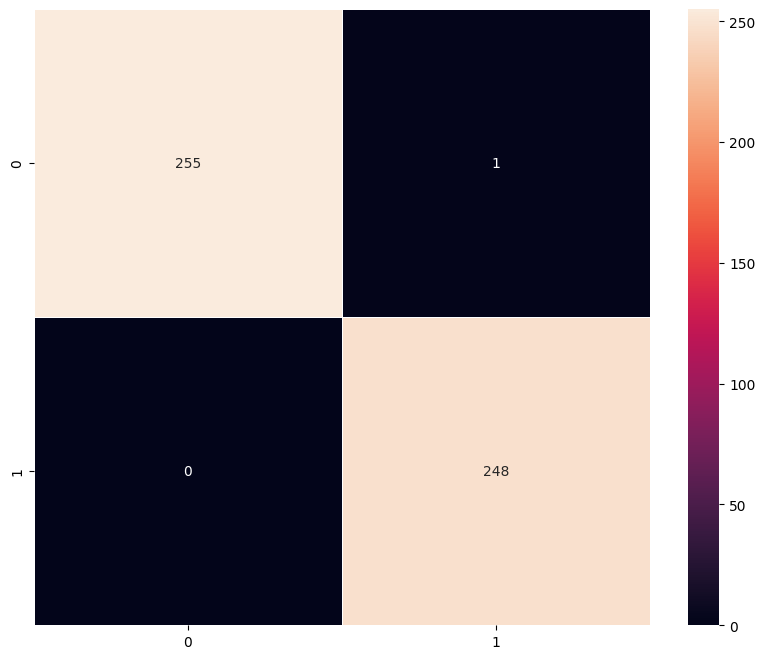

```python
plot_confusion_matrix(model_1,X_train_normalized,y_train_encoded)
```

This code evaluates your first CNN model (model_1) using unseen validation data (X_val_normalized, y_val_encoded). It calls a function model_performance_classification to calculate key metrics like Accuracy, Recall, Precision, and F1 Score. The results are stored in model_1_valid_perf and then printed. This step is essential to understand how well your model generalizes beyond the training data and helps detect issues like overfitting.

```python
model_1_valid_perf = model_performance_classification(model_1, X_val_normalized,y_val_encoded)

print("Validation performance metrics")
print(model_1_valid_perf)
```

```
2/2 ━━━━━━━━━━━━━━━━━━━━ 0s 76ms/step
Validation performance metrics
   Accuracy  Recall  Precision  F1 Score
0       1.0     1.0        1.0       1.0
```

This code calls the plot_confusion_matrix function with your trained model (model_1), normalized validation images (X_val_normalized), and encoded validation labels (y_val_encoded). It creates and displays a confusion matrix. This matrix shows how many images from the validation set were correctly and incorrectly classified by your model into the "With Helmet" and "Without Helmet" categories. It helps you see how well your model performs on unseen data and identify where it might be making mistakes.

```python
plot_confusion_matrix(model_1,X_val_normalized,y_val_encoded)
```

[output not shown]

```
2/2 ━━━━━━━━━━━━━━━━━━━━ 0s 72ms/step
```

### Vizualizing the predictions

This code snippet visually checks the performance of your trained image classification model on a few validation images. For three different images from the validation set, it first displays the image using matplotlib. Then, it uses your model to predict the label ("With Helmet" or "Without Helmet") for that image. Finally, it prints both the model's predicted label and the actual true label for comparison. This helps you see if the model is correctly classifying these specific examples.

```python
# Visualizing the predicted and correct label of images from test data
plt.figure(figsize=(2,2))
plt.imshow(X_val[2])
plt.show()
print('Predicted Label', enc.inverse_transform(model_1.predict((X_val_normalized[2].reshape(1,64,64,3)))))   # reshaping the input image as we are only trying to predict using a single image
print('True Label', enc.inverse_transform(y_val_encoded)[2])                                               # using inverse_transform() to get the output label from the output vector

plt.figure(figsize=(2,2))
plt.imshow(X_val[10])
plt.show()
print('Predicted Label', enc.inverse_transform(model_1.predict((X_val_normalized[10].reshape(1,64,64,3)))))  # reshaping the input image as we are only trying to predict using a single image
print('True Label', enc.inverse_transform(y_val_encoded)[10])                                              # using inverse_transform() to get the output label from the output vector

plt.figure(figsize=(2,2))
plt.imshow(X_val[23])
plt.show()
print('Predicted Label', enc.inverse_transform(model_1.predict((X_val_normalized[23].reshape(1,64,64,3)))))  # reshaping the input image as we are only trying to predict using a single image
print('True Label', enc.inverse_transform(y_val_encoded)[23])                                              # using inverse_transform() to get the output label from the output vector
```

[output not shown]

```
1/1 ━━━━━━━━━━━━━━━━━━━━ 0s 66ms/step
Predicted Label [0]
True Label 0
```

```
1/1 ━━━━━━━━━━━━━━━━━━━━ 0s 284ms/step
Predicted Label [1]
True Label 1
```

```
1/1 ━━━━━━━━━━━━━━━━━━━━ 0s 63ms/step
Predicted Label [1]
True Label 1
```

**Training Performance:**

Accuracy: 0.9980

Recall: 0.9980

Precision: 0.9980

F1 Score: 0.9980

**Validation Performance:**

Accuracy: 1.000

Recall: 1.000

Precision: 1.000

F1 Score: 1.000

**Analysis:**

Model 1 shows near-perfect performance on the training set and perfect performance on the validation set.

While this indicates excellent generalization, the slightly higher validation accuracy compared to training could suggest:

A simpler validation set, Potential data leakage, or

An overfit model that coincidentally performs well on the validation set.

## Model 2: (VGG-16 (Base))

We're loading a powerful pre-trained image recognition model called VGG16, trained on the vast ImageNet dataset. The key is include_top=False, which removes its original classification layers, letting you add your own for your specific helmet detection task. input_shape=(64,64,3) sets the image size the model expects. vgg_model.summary() shows the layers you've kept from the original VGG16, ready for transfer learning. This leverages existing knowledge for faster and better model development.

```python
vgg_model = VGG16(weights='imagenet',include_top=False,input_shape=(64,64,3))
vgg_model.summary()
```

```
Model: "vgg16"
```

```
┏━━━━━━━━━━━━━━━━━━━━━━━━━━━━━━━━━┳━━━━━━━━━━━━━━━━━━━━━━━━┳━━━━━━━━━━━━━━━┓
┃ Layer (type)                    ┃ Output Shape           ┃       Param # ┃
┡━━━━━━━━━━━━━━━━━━━━━━━━━━━━━━━━━╇━━━━━━━━━━━━━━━━━━━━━━━━╇━━━━━━━━━━━━━━━┩
│ input_layer_1 (InputLayer)      │ (None, 64, 64, 3)      │             0 │
├─────────────────────────────────┼────────────────────────┼───────────────┤
│ block1_conv1 (Conv2D)           │ (None, 64, 64, 64)     │         1,792 │
├─────────────────────────────────┼────────────────────────┼───────────────┤
│ block1_conv2 (Conv2D)           │ (None, 64, 64, 64)     │        36,928 │
├─────────────────────────────────┼────────────────────────┼───────────────┤
│ block1_pool (MaxPooling2D)      │ (None, 32, 32, 64)     │             0 │
├─────────────────────────────────┼────────────────────────┼───────────────┤
│ block2_conv1 (Conv2D)           │ (None, 32, 32, 128)    │        73,856 │
├─────────────────────────────────┼────────────────────────┼───────────────┤
│ block2_conv2 (Conv2D)           │ (None, 32, 32, 128)    │       147,584 │
├─────────────────────────────────┼────────────────────────┼───────────────┤
│ block2_pool (MaxPooling2D)      │ (None, 16, 16, 128)    │             0 │
├─────────────────────────────────┼────────────────────────┼───────────────┤
│ block3_conv1 (Conv2D)           │ (None, 16, 16, 256)    │       295,168 │
├─────────────────────────────────┼────────────────────────┼───────────────┤
│ block3_conv2 (Conv2D)           │ (None, 16, 16, 256)    │       590,080 │
├─────────────────────────────────┼────────────────────────┼───────────────┤
│ block3_conv3 (Conv2D)           │ (None, 16, 16, 256)    │       590,080 │
├─────────────────────────────────┼────────────────────────┼───────────────┤
│ block3_pool (MaxPooling2D)      │ (None, 8, 8, 256)      │             0 │
├─────────────────────────────────┼────────────────────────┼───────────────┤
│ block4_conv1 (Conv2D)           │ (None, 8, 8, 512)      │     1,180,160 │
├─────────────────────────────────┼────────────────────────┼───────────────┤
│ block4_conv2 (Conv2D)           │ (None, 8, 8, 512)      │     2,359,808 │
├─────────────────────────────────┼────────────────────────┼───────────────┤
│ block4_conv3 (Conv2D)           │ (None, 8, 8, 512)      │     2,359,808 │
├─────────────────────────────────┼────────────────────────┼───────────────┤
│ block4_pool (MaxPooling2D)      │ (None, 4, 4, 512)      │             0 │
├─────────────────────────────────┼────────────────────────┼───────────────┤
│ block5_conv1 (Conv2D)           │ (None, 4, 4, 512)      │     2,359,808 │
├─────────────────────────────────┼────────────────────────┼───────────────┤
│ block5_conv2 (Conv2D)           │ (None, 4, 4, 512)      │     2,359,808 │
├─────────────────────────────────┼────────────────────────┼───────────────┤
│ block5_conv3 (Conv2D)           │ (None, 4, 4, 512)      │     2,359,808 │
├─────────────────────────────────┼────────────────────────┼───────────────┤
│ block5_pool (MaxPooling2D)      │ (None, 2, 2, 512)      │             0 │
└─────────────────────────────────┴────────────────────────┴───────────────┘
```

```
 Total params: 14,714,688 (56.13 MB)
```

```
 Trainable params: 14,714,688 (56.13 MB)
```

```
 Non-trainable params: 0 (0.00 B)
```

```python
# Making all the layers of the VGG model non-trainable. i.e. freezing them
for layer in vgg_model.layers:
    layer.trainable = False
```

This code builds a neural network named model_2 by stacking layers. It starts with a pre-trained VGG16 model (vgg_model) to extract powerful image features. The Flatten layer then converts these features into a single vector. Finally, a Dense layer with 3 units and softmax activation predicts the probability of the image belonging to one of three classes. This approach leverages transfer learning from the pre-trained VGG16 to build an image classification model.

```python
model_2 = Sequential()

# Adding the convolutional part of the VGG16 model from above
model_2.add(vgg_model)

# Flattening the output of the VGG16 model because it is from a convolutional layer
model_2.add(Flatten())

# Adding a dense output layer
model_2.add(Dense(3, activation='softmax'))
```

```python
opt=Adam()
# Compile model
# Other metrics like precision,f1_score,recall can be used
model_2.compile(optimizer=opt, loss='categorical_crossentropy', metrics=['accuracy'])
```

```python
# Generating the summary of the model
model_2.summary()
```

```
Model: "sequential_1"
```

```
┏━━━━━━━━━━━━━━━━━━━━━━━━━━━━━━━━━┳━━━━━━━━━━━━━━━━━━━━━━━━┳━━━━━━━━━━━━━━━┓
┃ Layer (type)                    ┃ Output Shape           ┃       Param # ┃
┡━━━━━━━━━━━━━━━━━━━━━━━━━━━━━━━━━╇━━━━━━━━━━━━━━━━━━━━━━━━╇━━━━━━━━━━━━━━━┩
│ vgg16 (Functional)              │ (None, 2, 2, 512)      │    14,714,688 │
├─────────────────────────────────┼────────────────────────┼───────────────┤
│ flatten_1 (Flatten)             │ (None, 2048)           │             0 │
├─────────────────────────────────┼────────────────────────┼───────────────┤
│ dense_2 (Dense)                 │ (None, 3)              │         6,147 │
└─────────────────────────────────┴────────────────────────┴───────────────┘
```

```
 Total params: 14,720,835 (56.16 MB)
```

```
 Trainable params: 6,147 (24.01 KB)
```

```
 Non-trainable params: 14,714,688 (56.13 MB)
```

```python
train_datagen = ImageDataGenerator()
```

```python
# Build the Sequential model using the VGG16 base
model_2 = Sequential()

# Adding the convolutional part of the VGG16 model
model_2.add(vgg_model)

# Flattening the output of the VGG16 model
model_2.add(Flatten())

# Adding a dense output layer for binary classification
# Change the output units to 1 and activation to 'sigmoid' for binary classification
model_2.add(Dense(1, activation='sigmoid'))

# Use Adam optimizer
opt = Adam()

# Compile model for binary classification
# Change the loss function to 'binary_crossentropy'
model_2.compile(optimizer=opt, loss='binary_crossentropy', metrics=['accuracy'])

# Generating the summary of the model
model_2.summary()

# Data augmentation generator (already defined as train_datagen = ImageDataGenerator())

# Epochs
epochs = 20
# Batch size
batch_size = 128

# Fit the model using the data generator
history_vgg16 = model_2.fit(train_datagen.flow(X_train_normalized, y_train_encoded,
                                       batch_size=batch_size,
                                       seed=42,
                                       shuffle=False),
                    epochs=epochs,
                    steps_per_epoch=X_train_normalized.shape[0] // batch_size,
                    validation_data=(X_val_normalized, y_val_encoded),
                    verbose=1)
```

```
Model: "sequential_7"
```

```
┏━━━━━━━━━━━━━━━━━━━━━━━━━━━━━━━━━┳━━━━━━━━━━━━━━━━━━━━━━━━┳━━━━━━━━━━━━━━━┓
┃ Layer (type)                    ┃ Output Shape           ┃       Param # ┃
┡━━━━━━━━━━━━━━━━━━━━━━━━━━━━━━━━━╇━━━━━━━━━━━━━━━━━━━━━━━━╇━━━━━━━━━━━━━━━┩
│ vgg16 (Functional)              │ (None, 2, 2, 512)      │    14,714,688 │
├─────────────────────────────────┼────────────────────────┼───────────────┤
│ flatten_7 (Flatten)             │ (None, 2048)           │             0 │
├─────────────────────────────────┼────────────────────────┼───────────────┤
│ dense_16 (Dense)                │ (None, 1)              │         2,049 │
└─────────────────────────────────┴────────────────────────┴───────────────┘
```

```
 Total params: 14,716,737 (56.14 MB)
```

```
 Trainable params: 2,049 (8.00 KB)
```

```
 Non-trainable params: 14,714,688 (56.13 MB)
```

```
3/3 ━━━━━━━━━━━━━━━━━━━━ 29s 9s/step - accuracy: 0.5309 - loss: 0.7421 - val_accuracy: 0.6825 - val_loss: 0.5506
3/3 ━━━━━━━━━━━━━━━━━━━━ 10s 3s/step - accuracy: 0.6583 - loss: 0.5978 - val_accuracy: 0.8730 - val_loss: 0.5087
3/3 ━━━━━━━━━━━━━━━━━━━━ 24s 8s/step - accuracy: 0.7969 - loss: 0.5468 - val_accuracy: 0.8889 - val_loss: 0.4167
3/3 ━━━━━━━━━━━━━━━━━━━━ 10s 3s/step - accuracy: 0.8417 - loss: 0.5266 - val_accuracy: 0.9365 - val_loss: 0.3905
3/3 ━━━━━━━━━━━━━━━━━━━━ 31s 8s/step - accuracy: 0.8764 - loss: 0.4695 - val_accuracy: 0.9841 - val_loss: 0.3223
3/3 ━━━━━━━━━━━━━━━━━━━━ 11s 3s/step - accuracy: 0.9531 - loss: 0.3774 - val_accuracy: 1.0000 - val_loss: 0.3037
3/3 ━━━━━━━━━━━━━━━━━━━━ 28s 8s/step - accuracy: 0.9368 - loss: 0.3848 - val_accuracy: 1.0000 - val_loss: 0.2610
3/3 ━━━━━━━━━━━━━━━━━━━━ 12s 3s/step - accuracy: 0.9453 - loss: 0.3495 - val_accuracy: 1.0000 - val_loss: 0.2498
3/3 ━━━━━━━━━━━━━━━━━━━━ 31s 9s/step - accuracy: 0.9606 - loss: 0.3134 - val_accuracy: 0.9841 - val_loss: 0.2217
3/3 ━━━━━━━━━━━━━━━━━━━━ 11s 3s/step - accuracy: 1.0000 - loss: 0.2645 - val_accuracy: 0.9841 - val_loss: 0.2124
```

[output not shown]

[output cut: 39 more lines]

[output not shown]

[figure not shown]

```python
plt.plot(history_vgg16.history['accuracy'])
plt.plot(history_vgg16.history['val_accuracy'])
plt.title('Model Accuracy')
plt.ylabel('Accuracy')
plt.xlabel('Epoch')
plt.legend(['Train', 'Validation'], loc='upper left')
plt.show()
```

```python
model_2_train_perf = model_performance_classification(model_2, X_train_normalized,y_train_encoded)

print("Train performance metrics")
print(model_2_train_perf)
```

```
16/16 ━━━━━━━━━━━━━━━━━━━━ 26s 2s/step
Train performance metrics
   Accuracy    Recall  Precision  F1 Score
0  0.998016  0.998016   0.998024  0.998016
```

```
16/16 ━━━━━━━━━━━━━━━━━━━━ 25s 2s/step
```

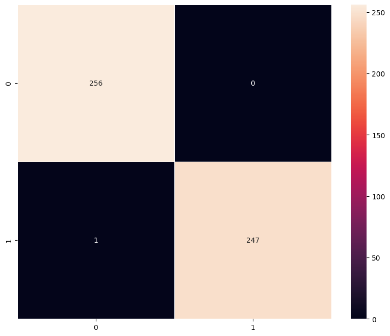

```python
plot_confusion_matrix(model_2,X_train_normalized,y_train_encoded)
```

```python
model_2_valid_perf = model_performance_classification(model_2, X_val_normalized,y_val_encoded)

print("Validation performance metrics")
print(model_2_valid_perf)
```

```
2/2 ━━━━━━━━━━━━━━━━━━━━ 3s 1s/step
Validation performance metrics
   Accuracy  Recall  Precision  F1 Score
0       1.0     1.0        1.0       1.0
```

```python
plot_confusion_matrix(model_2,X_val_normalized,y_val_encoded)
```

[output not shown]

```
2/2 ━━━━━━━━━━━━━━━━━━━━ 3s 1s/step
```

### Visualizing the prediction:

```python
# Visualizing the predicted and correct label of images from test data
plt.figure(figsize=(2,2))
plt.imshow(X_val[2])
plt.show()
print('Predicted Label', enc.inverse_transform(model_2.predict((X_val_normalized[2].reshape(1,64,64,3)))))   # reshaping the input image as we are only trying to predict using a single image
print('True Label', enc.inverse_transform(y_val_encoded)[2])                                               # using inverse_transform() to get the output label from the output vector

plt.figure(figsize=(2,2))
plt.imshow(X_val[10])
plt.show()
print('Predicted Label', enc.inverse_transform(model_2.predict((X_val_normalized[10].reshape(1,64,64,3)))))  # reshaping the input image as we are only trying to predict using a single image
print('True Label', enc.inverse_transform(y_val_encoded)[10])                                              # using inverse_transform() to get the output label from the output vector

plt.figure(figsize=(2,2))
plt.imshow(X_val[23])
plt.show()
print('Predicted Label', enc.inverse_transform(model_2.predict((X_val_normalized[23].reshape(1,64,64,3)))))  # reshaping the input image as we are only trying to predict using a single image
print('True Label', enc.inverse_transform(y_val_encoded)[23])                                              # using inverse_transform() to get the output label from the output vector
```

[output not shown]

```
1/1 ━━━━━━━━━━━━━━━━━━━━ 0s 160ms/step
Predicted Label [0]
True Label 0
```

```
1/1 ━━━━━━━━━━━━━━━━━━━━ 0s 164ms/step
Predicted Label [1]
True Label 1
```

```
1/1 ━━━━━━━━━━━━━━━━━━━━ 0s 162ms/step
Predicted Label [1]
True Label 1
```

**Model 2** **Training Performance:**

Accuracy: 0.9980

Recall: 0.9980

Precision: 0.9980

F1 Score: 0.9980

**Validation Performance:**

Accuracy: 1.000

Recall: 1.000

Precision: 1.000

F1 Score: 1.000

Model 2 performs flawlessly on the validation data. Given that the training score is slightly lower than validation, it may indicate that the validation set is either too simple or not representative of unseen edge cases.

## Model 3: (VGG-16 (Base + FFNN))

This Python code defines a neural network model. It starts with a pre-trained VGG16 model to extract features from images. Then, it flattens these features into a single vector. This is followed by two dense layers with ReLU activation and a dropout layer to prevent overfitting. Finally, an output layer with 3 neurons and softmax activation is added for classifying images into three categories based on the extracted features. This structure allows the model to learn and predict image classes.

```python
model_2 = Sequential()

# Adding the convolutional part of the VGG16 model from above
model_2.add(vgg_model)

# Flattening the output of the VGG16 model because it is from a convolutional layer
model_2.add(Flatten())

#Adding the Feed Forward neural network
model_2.add(Dense(256,activation='relu'))
model_2.add(Dropout(rate=0.4))
model_2.add(Dense(32,activation='relu'))

# Adding a dense output layer
model_2.add(Dense(3, activation='softmax'))
```

```python
opt = Adam()
```

```python
# Compile model
model_2.compile(optimizer=opt, loss='categorical_crossentropy', metrics=['accuracy'])
```

```python
# Generating the summary of the model
model_2.summary()
```

```
Model: "sequential_3"
```

```
┏━━━━━━━━━━━━━━━━━━━━━━━━━━━━━━━━━┳━━━━━━━━━━━━━━━━━━━━━━━━┳━━━━━━━━━━━━━━━┓
┃ Layer (type)                    ┃ Output Shape           ┃       Param # ┃
┡━━━━━━━━━━━━━━━━━━━━━━━━━━━━━━━━━╇━━━━━━━━━━━━━━━━━━━━━━━━╇━━━━━━━━━━━━━━━┩
│ vgg16 (Functional)              │ (None, 2, 2, 512)      │    14,714,688 │
├─────────────────────────────────┼────────────────────────┼───────────────┤
│ flatten_3 (Flatten)             │ (None, 2048)           │             0 │
├─────────────────────────────────┼────────────────────────┼───────────────┤
│ dense_4 (Dense)                 │ (None, 256)            │       524,544 │
├─────────────────────────────────┼────────────────────────┼───────────────┤
│ dropout (Dropout)               │ (None, 256)            │             0 │
├─────────────────────────────────┼────────────────────────┼───────────────┤
│ dense_5 (Dense)                 │ (None, 32)             │         8,224 │
├─────────────────────────────────┼────────────────────────┼───────────────┤
│ dense_6 (Dense)                 │ (None, 3)              │            99 │
└─────────────────────────────────┴────────────────────────┴───────────────┘
```

```
 Total params: 15,247,555 (58.16 MB)
```

```
 Trainable params: 532,867 (2.03 MB)
```

```
 Non-trainable params: 14,714,688 (56.13 MB)
```

This code builds a neural network model (model_3) to classify images of workers with or without helmets. It uses a pre-trained VGG-16 model as a foundation to extract important features from the images. The model then adds a small feed-forward neural network with dense layers and dropout (to help prevent the model from just memorizing the training data) to process these features. The final output layer has one neuron with a sigmoid activation, perfect for binary classification tasks like this, predicting the probability of an image showing a worker with a helmet. The model is compiled with the Adam optimizer and binary cross-entropy loss, standard choices for this type of problem. Finally, it trains the model for 20 epochs using your normalized training data, providing updates on its progress and evaluating its performance on a separate validation set.

```python
# Build the Sequential model using the VGG16 base
model_3 = Sequential()

# Adding the convolutional part of the VGG16 model
model_3.add(vgg_model)

# Flattening the output of the VGG16 model
model_3.add(Flatten())

#Adding the Feed Forward neural network
model_3.add(Dense(256,activation='relu'))
model_3.add(Dropout(rate=0.4))
model_3.add(Dense(32,activation='relu'))

# Adding a dense output layer for binary classification
# Change the output units to 1 and activation to 'sigmoid' for binary classification
model_3.add(Dense(1, activation='sigmoid'))

# Use Adam optimizer
opt = Adam()

# Compile model for binary classification
# Change the loss function to 'binary_crossentropy'
model_3.compile(optimizer=opt, loss='binary_crossentropy', metrics=['accuracy'])

# Generating the summary of the model
model_3.summary()

# Data augmentation generator (already defined as train_datagen = ImageDataGenerator())

# Epochs
epochs = 20
# Batch size
batch_size = 128

# Fit the model using the data generator
history_vgg16 = model_3.fit(train_datagen.flow(X_train_normalized, y_train_encoded,
                                       batch_size=batch_size,
                                       seed=42,
                                       shuffle=False),
                    epochs=epochs,
                    steps_per_epoch=X_train_normalized.shape[0] // batch_size,
                    validation_data=(X_val_normalized, y_val_encoded),
                    verbose=1)
```

```
Model: "sequential_4"
```

```
┏━━━━━━━━━━━━━━━━━━━━━━━━━━━━━━━━━┳━━━━━━━━━━━━━━━━━━━━━━━━┳━━━━━━━━━━━━━━━┓
┃ Layer (type)                    ┃ Output Shape           ┃       Param # ┃
┡━━━━━━━━━━━━━━━━━━━━━━━━━━━━━━━━━╇━━━━━━━━━━━━━━━━━━━━━━━━╇━━━━━━━━━━━━━━━┩
│ vgg16 (Functional)              │ (None, 2, 2, 512)      │    14,714,688 │
├─────────────────────────────────┼────────────────────────┼───────────────┤
│ flatten_4 (Flatten)             │ (None, 2048)           │             0 │
├─────────────────────────────────┼────────────────────────┼───────────────┤
│ dense_7 (Dense)                 │ (None, 256)            │       524,544 │
├─────────────────────────────────┼────────────────────────┼───────────────┤
│ dropout_1 (Dropout)             │ (None, 256)            │             0 │
├─────────────────────────────────┼────────────────────────┼───────────────┤
│ dense_8 (Dense)                 │ (None, 32)             │         8,224 │
├─────────────────────────────────┼────────────────────────┼───────────────┤
│ dense_9 (Dense)                 │ (None, 1)              │            33 │
└─────────────────────────────────┴────────────────────────┴───────────────┘
```

```
 Total params: 15,247,489 (58.16 MB)
```

```
 Trainable params: 532,801 (2.03 MB)
```

```
 Non-trainable params: 14,714,688 (56.13 MB)
```

```
3/3 ━━━━━━━━━━━━━━━━━━━━ 24s 8s/step - accuracy: 0.6109 - loss: 0.6595 - val_accuracy: 1.0000 - val_loss: 0.2155
3/3 ━━━━━━━━━━━━━━━━━━━━ 13s 3s/step - accuracy: 0.9375 - loss: 0.2446 - val_accuracy: 0.9841 - val_loss: 0.1422
3/3 ━━━━━━━━━━━━━━━━━━━━ 30s 9s/step - accuracy: 0.9636 - loss: 0.1301 - val_accuracy: 1.0000 - val_loss: 0.0294
3/3 ━━━━━━━━━━━━━━━━━━━━ 11s 1s/step - accuracy: 0.9766 - loss: 0.0496 - val_accuracy: 1.0000 - val_loss: 0.0212
3/3 ━━━━━━━━━━━━━━━━━━━━ 24s 9s/step - accuracy: 0.9930 - loss: 0.0258 - val_accuracy: 1.0000 - val_loss: 0.0122
3/3 ━━━━━━━━━━━━━━━━━━━━ 12s 3s/step - accuracy: 0.9922 - loss: 0.0403 - val_accuracy: 1.0000 - val_loss: 0.0082
3/3 ━━━━━━━━━━━━━━━━━━━━ 26s 8s/step - accuracy: 0.9977 - loss: 0.0149 - val_accuracy: 1.0000 - val_loss: 0.0025
3/3 ━━━━━━━━━━━━━━━━━━━━ 12s 3s/step - accuracy: 1.0000 - loss: 0.0079 - val_accuracy: 1.0000 - val_loss: 0.0023
3/3 ━━━━━━━━━━━━━━━━━━━━ 33s 9s/step - accuracy: 1.0000 - loss: 0.0083 - val_accuracy: 1.0000 - val_loss: 0.0026
3/3 ━━━━━━━━━━━━━━━━━━━━ 12s 3s/step - accuracy: 0.9917 - loss: 0.0132 - val_accuracy: 1.0000 - val_loss: 0.0021
3/3 ━━━━━━━━━━━━━━━━━━━━ 29s 8s/step - accuracy: 1.0000 - loss: 0.0075 - val_accuracy: 1.0000 - val_loss: 0.0011
3/3 ━━━━━━━━━━━━━━━━━━━━ 11s 3s/step - accuracy: 1.0000 - loss: 0.0024 - val_accuracy: 1.0000 - val_loss: 0.0012
3/3 ━━━━━━━━━━━━━━━━━━━━ 30s 8s/step - accuracy: 0.9977 - loss: 0.0081 - val_accuracy: 1.0000 - val_loss: 0.0031
3/3 ━━━━━━━━━━━━━━━━━━━━ 8s 1s/step - accuracy: 1.0000 - loss: 6.6221e-04 - val_accuracy: 1.0000 - val_loss: 0.0039
3/3 ━━━━━━━━━━━━━━━━━━━━ 33s 9s/step - accuracy: 1.0000 - loss: 0.0039 - val_accuracy: 1.0000 - val_loss: 0.0032
3/3 ━━━━━━━━━━━━━━━━━━━━ 11s 3s/step - accuracy: 1.0000 - loss: 0.0046 - val_accuracy: 1.0000 - val_loss: 0.0021
3/3 ━━━━━━━━━━━━━━━━━━━━ 30s 9s/step - accuracy: 1.0000 - loss: 0.0017 - val_accuracy: 1.0000 - val_loss: 5.8924e-04
3/3 ━━━━━━━━━━━━━━━━━━━━ 8s 1s/step - accuracy: 1.0000 - loss: 6.3340e-04 - val_accuracy: 1.0000 - val_loss: 4.4538e-04
3/3 ━━━━━━━━━━━━━━━━━━━━ 33s 9s/step - accuracy: 1.0000 - loss: 2.6848e-04 - val_accuracy: 1.0000 - val_loss: 4.2748e-04
3/3 ━━━━━━━━━━━━━━━━━━━━ 8s 1s/step - accuracy: 1.0000 - loss: 0.0046 - val_accuracy: 1.0000 - val_loss: 4.2128e-04
```

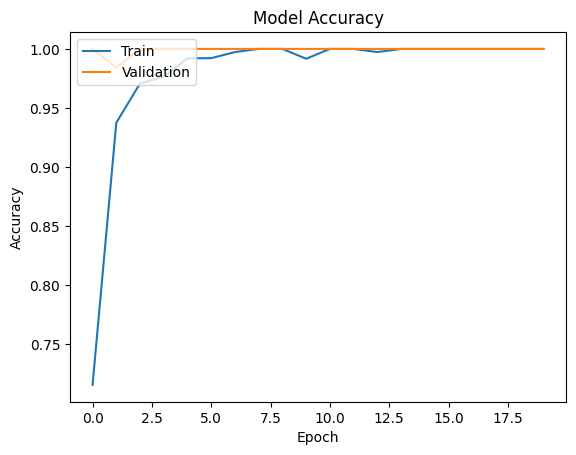

```python
plt.plot(history_vgg16.history['accuracy'])
plt.plot(history_vgg16.history['val_accuracy'])
plt.title('Model Accuracy')
plt.ylabel('Accuracy')
plt.xlabel('Epoch')
plt.legend(['Train', 'Validation'], loc='upper left')
plt.show()
```

```python
model_3_train_perf = model_performance_classification(model_3, X_train_normalized,y_train_encoded)

print("Train performance metrics")
print(model_3_train_perf)
```

```
16/16 ━━━━━━━━━━━━━━━━━━━━ 26s 2s/step
Train performance metrics
   Accuracy  Recall  Precision  F1 Score
0       1.0     1.0        1.0       1.0
```

```
16/16 ━━━━━━━━━━━━━━━━━━━━ 26s 2s/step
```

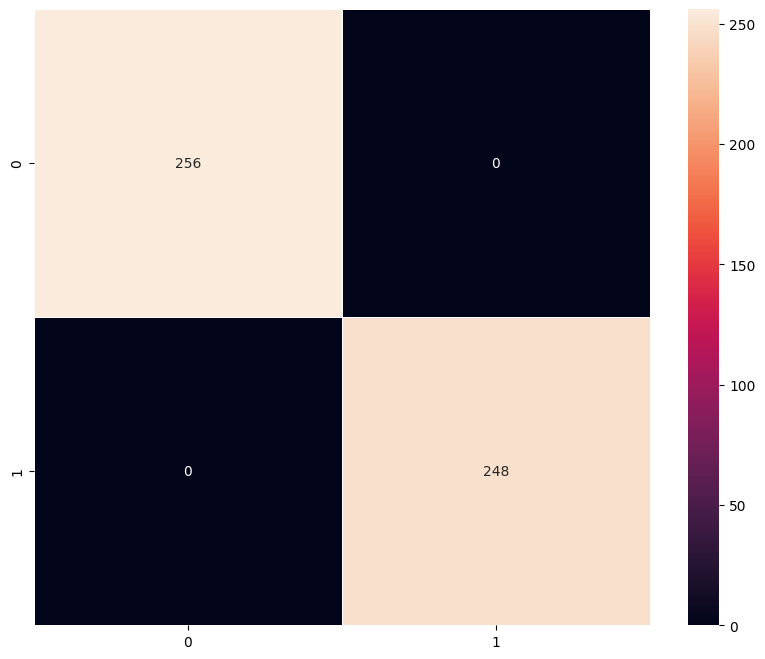

```python
plot_confusion_matrix(model_3,X_train_normalized,y_train_encoded)
```

```python
model_3_valid_perf = model_performance_classification(model_3, X_val_normalized,y_val_encoded)

print("Validation performance metrics")
print(model_3_valid_perf)
```

```
2/2 ━━━━━━━━━━━━━━━━━━━━ 3s 1s/step
Validation performance metrics
   Accuracy  Recall  Precision  F1 Score
0       1.0     1.0        1.0       1.0
```

```python
plot_confusion_matrix(model_3,X_val_normalized,y_val_encoded)
```

[output not shown]

```
2/2 ━━━━━━━━━━━━━━━━━━━━ 3s 1s/step
```

#### Visualizing the predictions

```python
# Visualizing the predicted and correct label of images from test data
plt.figure(figsize=(2,2))
plt.imshow(X_val[2])
plt.show()
print('Predicted Label', enc.inverse_transform(model_3.predict((X_val_normalized[2].reshape(1,64,64,3)))))   # reshaping the input image as we are only trying to predict using a single image
print('True Label', enc.inverse_transform(y_val_encoded)[2])                                               # using inverse_transform() to get the output label from the output vector

plt.figure(figsize=(2,2))
plt.imshow(X_val[10])
plt.show()
print('Predicted Label', enc.inverse_transform(model_3.predict((X_val_normalized[10].reshape(1,64,64,3)))))  # reshaping the input image as we are only trying to predict using a single image
print('True Label', enc.inverse_transform(y_val_encoded)[10])                                              # using inverse_transform() to get the output label from the output vector

plt.figure(figsize=(2,2))
plt.imshow(X_val[23])
plt.show()
print('Predicted Label', enc.inverse_transform(model_3.predict((X_val_normalized[23].reshape(1,64,64,3)))))  # reshaping the input image as we are only trying to predict using a single image
print('True Label', enc.inverse_transform(y_val_encoded)[23])                                              # using inverse_transform() to get the output label from the output vector
```

[output not shown]

```
1/1 ━━━━━━━━━━━━━━━━━━━━ 0s 89ms/step
Predicted Label [0]
True Label 0
```

```
1/1 ━━━━━━━━━━━━━━━━━━━━ 0s 133ms/step
Predicted Label [1]
True Label 1
```

```
1/1 ━━━━━━━━━━━━━━━━━━━━ 0s 155ms/step
Predicted Label [1]
True Label 1
```

Model 3 Training Performance:

Accuracy: 1.000

Recall: 1.000

Precision: 1.000

F1 Score: 1.000

Validation Performance:

Accuracy: 1.000

Recall: 1.000

Precision: 1.000

F1 Score: 1.000

Analysis: Model 3 demonstrates perfect scores on both training and validation sets, which raises red flags:

It may have memorized the data (overfitting), Or it’s a sign of data leakage or overly clean/class-separated data.

## Model 4: (VGG-16 (Base + FFNN + Data Augmentation)

- In most of the real-world case studies, it is challenging to acquire a large number of images and then train CNNs.
- To overcome this problem, one approach we might consider is **Data Augmentation**.
- CNNs have the property of **translational invariance**, which means they can recognise an object even if its appearance shifts translationally in some way. - Taking this attribute into account, we can augment the images using the techniques listed below
  - Horizontal Flip (should be set to True/False)
  - Vertical Flip (should be set to True/False)
  - Height Shift (should be between 0 and 1)
  - Width Shift (should be between 0 and 1)
  - Rotation (should be between 0 and 180)
  - Shear (should be between 0 and 1)
  - Zoom (should be between 0 and 1) etc.

Remember, **data augmentation should not be used in the validation/test data set**.

This code defines model_4, an image classification model. It starts with Sequential() to create a linear stack of layers. The pre-trained VGG16 model (vgg_model), without its original classifier, is added first to extract image features. Flatten() converts the VGG16 output into a single vector. A custom feed-forward network is then added with a Dense layer (256 neurons, ReLU activation), a Dropout layer (40% rate) to prevent overfitting, and another Dense layer (32 neurons, ReLU). Finally, a Dense output layer with 3 neurons and softmax activation prepares the model for multi-class classification.

```python
model_4 = Sequential()

# Adding the convolutional part of the VGG16 model from above
model_4.add(vgg_model)

# Flattening the output of the VGG16 model because it is from a convolutional layer
model_4.add(Flatten())

#Adding the Feed Forward neural network
model_4.add(Dense(256,activation='relu'))
model_4.add(Dropout(rate=0.4))
model_4.add(Dense(32,activation='relu'))

# Adding a dense output layer
model_4.add(Dense(3, activation='softmax'))
```

This code snippet model_4.compile(optimizer=opt, loss='categorical_crossentropy', metrics=['accuracy']) is the crucial step of preparing your neural network model (model_4) for training.

It uses the .compile() method to configure the learning process.

optimizer=opt: This tells the model to use the Adam optimization algorithm (stored in the opt variable) to adjust its internal settings and learn from the data. loss='categorical_crossentropy': This sets the objective function the model will try to minimize. 'categorical_crossentropy' is suitable for classifying data into multiple categories and measures how well the model's predictions match the true labels. metrics=['accuracy']: This specifies that the model's performance will be evaluated by tracking 'accuracy', which is the percentage of correct predictions. Essentially, this line equips the model with the 'how-to' for learning and the 'how-well' for evaluation.

```python
opt=Adam()
# Compile model
model_4.compile(optimizer=opt, loss='categorical_crossentropy', metrics=['accuracy'])
```

This code sets up data augmentation for training images using ImageDataGenerator. It randomly transforms images by rotating (rotation_range), shifting horizontally and vertically (width_shift_range, height_shift_range), shearing (shear_range), and zooming (zoom_range). fill_mode='nearest' handles filling in pixels after transformations. This process creates varied training examples from the original dataset, making the model more robust and better at recognizing helmets in different appearances, ultimately improving its performance on unseen data.

```python
# Applying data augmentation
train_datagen = ImageDataGenerator(
                              rotation_range=20,
                              fill_mode='nearest',width_shift_range=0.2,height_shift_range=0.2,shear_range=0.3,zoom_range=0.4
                              )
```

```python
# Generating the summary of the model
model_4.summary()
```

```
Model: "sequential_5"
```

```
┏━━━━━━━━━━━━━━━━━━━━━━━━━━━━━━━━━┳━━━━━━━━━━━━━━━━━━━━━━━━┳━━━━━━━━━━━━━━━┓
┃ Layer (type)                    ┃ Output Shape           ┃       Param # ┃
┡━━━━━━━━━━━━━━━━━━━━━━━━━━━━━━━━━╇━━━━━━━━━━━━━━━━━━━━━━━━╇━━━━━━━━━━━━━━━┩
│ vgg16 (Functional)              │ (None, 2, 2, 512)      │    14,714,688 │
├─────────────────────────────────┼────────────────────────┼───────────────┤
│ flatten_5 (Flatten)             │ (None, 2048)           │             0 │
├─────────────────────────────────┼────────────────────────┼───────────────┤
│ dense_10 (Dense)                │ (None, 256)            │       524,544 │
├─────────────────────────────────┼────────────────────────┼───────────────┤
│ dropout_2 (Dropout)             │ (None, 256)            │             0 │
├─────────────────────────────────┼────────────────────────┼───────────────┤
│ dense_11 (Dense)                │ (None, 32)             │         8,224 │
├─────────────────────────────────┼────────────────────────┼───────────────┤
│ dense_12 (Dense)                │ (None, 3)              │            99 │
└─────────────────────────────────┴────────────────────────┴───────────────┘
```

```
 Total params: 15,247,555 (58.16 MB)
```

```
 Trainable params: 532,867 (2.03 MB)
```

```
 Non-trainable params: 14,714,688 (56.13 MB)
```

This code defines, compiles, and trains model_4 for helmet detection. It uses transfer learning by starting with vgg_model, a pre-trained VGG16 network (without its final classification layer), to extract image features. The output of VGG16 is flattened and fed into a custom feed-forward network with dense layers and dropout to learn complex patterns and prevent overfitting. A single-neuron dense layer with a sigmoid activation outputs the probability of an image containing a worker with a helmet, making it suitable for binary classification.

The model is compiled with the Adam optimizer and binary_crossentropy loss. Data augmentation is applied to the training images using ImageDataGenerator, creating variations like rotations, shifts, and zooms to make the model more robust. The model is then trained on these augmented images and evaluated on a separate validation set for 20 epochs. The training progress and performance metrics are tracked throughout the process.

```python
model_4 = Sequential()

# Adding the convolutional part of the VGG16 model from above
model_4.add(vgg_model)

# Flattening the output of the VGG16 model because it is from a convolutional layer
model_4.add(Flatten())

#Adding the Feed Forward neural network
model_4.add(Dense(256,activation='relu'))
model_4.add(Dropout(rate=0.4))
model_4.add(Dense(32,activation='relu'))

# Adding a dense output layer
# Corrected to 1 unit and 'sigmoid' activation for binary classification
model_4.add(Dense(1, activation='sigmoid'))

opt=Adam()
# Compile model
# Corrected to 'binary_crossentropy' for binary classification
model_4.compile(optimizer=opt, loss='binary_crossentropy', metrics=['accuracy'])

# Applying data augmentation
train_datagen = ImageDataGenerator(
                              rotation_range=20,
                              fill_mode='nearest',width_shift_range=0.2,height_shift_range=0.2,shear_range=0.3,zoom_range=0.4
                              )

# Generating the summary of the model
model_4.summary()

# Define epochs and batch_size if not already defined
# epochs = 20 # Uncomment and set the desired number of epochs
# batch_size = 128 # Uncomment and set the desired batch size

history_vgg16 = model_4.fit(train_datagen.flow(X_train_normalized,y_train_encoded,
                                       batch_size=batch_size,
                                       seed=42,
                                       shuffle=False),
                    epochs=epochs,
                    steps_per_epoch=X_train_normalized.shape[0] // batch_size,
                    validation_data=(X_val_normalized,y_val_encoded),
                    verbose=1)
```

```
Model: "sequential_6"
```

```
┏━━━━━━━━━━━━━━━━━━━━━━━━━━━━━━━━━┳━━━━━━━━━━━━━━━━━━━━━━━━┳━━━━━━━━━━━━━━━┓
┃ Layer (type)                    ┃ Output Shape           ┃       Param # ┃
┡━━━━━━━━━━━━━━━━━━━━━━━━━━━━━━━━━╇━━━━━━━━━━━━━━━━━━━━━━━━╇━━━━━━━━━━━━━━━┩
│ vgg16 (Functional)              │ (None, 2, 2, 512)      │    14,714,688 │
├─────────────────────────────────┼────────────────────────┼───────────────┤
│ flatten_6 (Flatten)             │ (None, 2048)           │             0 │
├─────────────────────────────────┼────────────────────────┼───────────────┤
│ dense_13 (Dense)                │ (None, 256)            │       524,544 │
├─────────────────────────────────┼────────────────────────┼───────────────┤
│ dropout_3 (Dropout)             │ (None, 256)            │             0 │
├─────────────────────────────────┼────────────────────────┼───────────────┤
│ dense_14 (Dense)                │ (None, 32)             │         8,224 │
├─────────────────────────────────┼────────────────────────┼───────────────┤
│ dense_15 (Dense)                │ (None, 1)              │            33 │
└─────────────────────────────────┴────────────────────────┴───────────────┘
```

```
 Total params: 15,247,489 (58.16 MB)
```

```
 Trainable params: 532,801 (2.03 MB)
```

```
 Non-trainable params: 14,714,688 (56.13 MB)
```

```
3/3 ━━━━━━━━━━━━━━━━━━━━ 27s 10s/step - accuracy: 0.6499 - loss: 0.6561 - val_accuracy: 1.0000 - val_loss: 0.1973
3/3 ━━━━━━━━━━━━━━━━━━━━ 13s 3s/step - accuracy: 0.8203 - loss: 0.3851 - val_accuracy: 1.0000 - val_loss: 0.1295
3/3 ━━━━━━━━━━━━━━━━━━━━ 29s 9s/step - accuracy: 0.9271 - loss: 0.2566 - val_accuracy: 0.9524 - val_loss: 0.0885
3/3 ━━━━━━━━━━━━━━━━━━━━ 11s 3s/step - accuracy: 0.9453 - loss: 0.1585 - val_accuracy: 0.9524 - val_loss: 0.0722
3/3 ━━━━━━━━━━━━━━━━━━━━ 24s 9s/step - accuracy: 0.9741 - loss: 0.0903 - val_accuracy: 1.0000 - val_loss: 0.0251
3/3 ━━━━━━━━━━━━━━━━━━━━ 10s 1s/step - accuracy: 0.9922 - loss: 0.0481 - val_accuracy: 1.0000 - val_loss: 0.0136
3/3 ━━━━━━━━━━━━━━━━━━━━ 32s 9s/step - accuracy: 0.9671 - loss: 0.0871 - val_accuracy: 1.0000 - val_loss: 0.0105
3/3 ━━━━━━━━━━━━━━━━━━━━ 10s 1s/step - accuracy: 0.9667 - loss: 0.0903 - val_accuracy: 1.0000 - val_loss: 0.0098
3/3 ━━━━━━━━━━━━━━━━━━━━ 31s 9s/step - accuracy: 0.9744 - loss: 0.0615 - val_accuracy: 0.9841 - val_loss: 0.0203
3/3 ━━━━━━━━━━━━━━━━━━━━ 12s 3s/step - accuracy: 0.9844 - loss: 0.0552 - val_accuracy: 0.9841 - val_loss: 0.0239
3/3 ━━━━━━━━━━━━━━━━━━━━ 29s 9s/step - accuracy: 0.9715 - loss: 0.0634 - val_accuracy: 0.9841 - val_loss: 0.0157
3/3 ━━━━━━━━━━━━━━━━━━━━ 11s 3s/step - accuracy: 0.9766 - loss: 0.0404 - val_accuracy: 1.0000 - val_loss: 0.0086
3/3 ━━━━━━━━━━━━━━━━━━━━ 24s 9s/step - accuracy: 0.9863 - loss: 0.0370 - val_accuracy: 1.0000 - val_loss: 0.0034
3/3 ━━━━━━━━━━━━━━━━━━━━ 12s 3s/step - accuracy: 0.9583 - loss: 0.0745 - val_accuracy: 1.0000 - val_loss: 0.0047
3/3 ━━━━━━━━━━━━━━━━━━━━ 30s 9s/step - accuracy: 0.9930 - loss: 0.0200 - val_accuracy: 0.9841 - val_loss: 0.0138
3/3 ━━━━━━━━━━━━━━━━━━━━ 11s 3s/step - accuracy: 0.9844 - loss: 0.0332 - val_accuracy: 0.9841 - val_loss: 0.0157
3/3 ━━━━━━━━━━━━━━━━━━━━ 28s 9s/step - accuracy: 0.9782 - loss: 0.0418 - val_accuracy: 1.0000 - val_loss: 0.0049
3/3 ━━━━━━━━━━━━━━━━━━━━ 8s 1s/step - accuracy: 0.9917 - loss: 0.0415 - val_accuracy: 1.0000 - val_loss: 0.0033
3/3 ━━━━━━━━━━━━━━━━━━━━ 25s 8s/step - accuracy: 0.9878 - loss: 0.0280 - val_accuracy: 1.0000 - val_loss: 0.0025
3/3 ━━━━━━━━━━━━━━━━━━━━ 8s 1s/step - accuracy: 0.9922 - loss: 0.0212 - val_accuracy: 1.0000 - val_loss: 0.0030
```

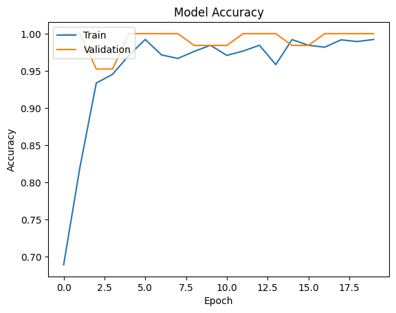

```python
plt.plot(history_vgg16.history['accuracy'])
plt.plot(history_vgg16.history['val_accuracy'])
plt.title('Model Accuracy')
plt.ylabel('Accuracy')
plt.xlabel('Epoch')
plt.legend(['Train', 'Validation'], loc='upper left')
plt.show()
```

```python
model_4_train_perf = model_performance_classification(model_4, X_train_normalized,y_train_encoded)

print("Train performance metrics")
print(model_4_train_perf)
```

```
16/16 ━━━━━━━━━━━━━━━━━━━━ 26s 2s/step
Train performance metrics
   Accuracy    Recall  Precision  F1 Score
0  0.998016  0.998016   0.998024  0.998016
```

```
16/16 ━━━━━━━━━━━━━━━━━━━━ 23s 1s/step
```

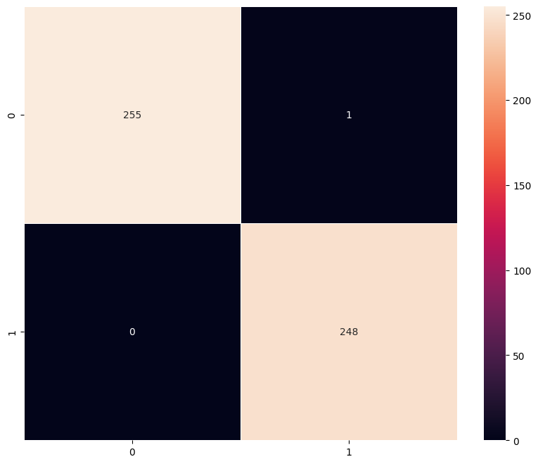

```python
plot_confusion_matrix(model_4,X_train_normalized,y_train_encoded)
```

```python
model_4_valid_perf = model_performance_classification(model_4, X_val_normalized,y_val_encoded)

print("Validation performance metrics")
print(model_4_valid_perf)
```

```
2/2 ━━━━━━━━━━━━━━━━━━━━ 3s 1s/step
Validation performance metrics
   Accuracy  Recall  Precision  F1 Score
0       1.0     1.0        1.0       1.0
```

```python
plot_confusion_matrix(model_4,X_val_normalized,y_val_encoded)
```

[output not shown]

```
2/2 ━━━━━━━━━━━━━━━━━━━━ 3s 2s/step
```

#### Visualizing the predictions

```python
# Visualizing the predicted and correct label of images from test data
plt.figure(figsize=(2,2))
plt.imshow(X_val[2])
plt.show()
print('Predicted Label', enc.inverse_transform(model_4.predict((X_val_normalized[2].reshape(1,64,64,3)))))   # reshaping the input image as we are only trying to predict using a single image
print('True Label', enc.inverse_transform(y_val_encoded)[2])                                               # using inverse_transform() to get the output label from the output vector

plt.figure(figsize=(2,2))
plt.imshow(X_val[10])
plt.show()
print('Predicted Label', enc.inverse_transform(model_4.predict((X_val_normalized[10].reshape(1,64,64,3)))))  # reshaping the input image as we are only trying to predict using a single image
print('True Label', enc.inverse_transform(y_val_encoded)[10])                                              # using inverse_transform() to get the output label from the output vector

plt.figure(figsize=(2,2))
plt.imshow(X_val[23])
plt.show()
print('Predicted Label', enc.inverse_transform(model_4.predict((X_val_normalized[23].reshape(1,64,64,3)))))  # reshaping the input image as we are only trying to predict using a single image
print('True Label', enc.inverse_transform(y_val_encoded)[23])                                              # using inverse_transform() to get the output label from the output vector
```

[output not shown]

```
1/1 ━━━━━━━━━━━━━━━━━━━━ 0s 150ms/step
Predicted Label [0]
True Label 0
```

```
1/1 ━━━━━━━━━━━━━━━━━━━━ 0s 135ms/step
Predicted Label [1]
True Label 1
```

```
1/1 ━━━━━━━━━━━━━━━━━━━━ 0s 146ms/step
Predicted Label [1]
True Label 1
```

Model 4 Training Performance:

Accuracy: 0.9980

Recall: 0.9980

Precision: 0.9980

F1 Score: 0.9980

Validation Performance:

Accuracy: 1.000

Recall: 1.000

Precision: 1.000

F1 Score: 1.000

Model 4 also reflects the same trend — high training accuracy and perfect validation accuracy — suggesting high consistency across different models.

# **Model Performance Comparison and Final Model Selection**

This code snippet combines the training performance results from four different machine learning models into a single table for easy comparison. Each model's performance metrics (like accuracy, precision, recall, and F1-score) on the training data are likely stored in variables named model_1_train_perf, model_2_train_perf, and so on.

The .T attached to each variable transposes the data, making the metrics the rows and preparing them for combining. pd.concat() is then used to stitch these transposed performance tables together column-wise, creating a comprehensive DataFrame called models_train_comp_df.

Finally, the column names of models_train_comp_df are set to descriptive labels like "CNN", "VGG-16 (Base)", etc., so you can easily see which set of metrics belongs to which model. This resulting table allows for a quick and direct comparison of how well each model learned from the training data.

```python
# training performance comparison

models_train_comp_df = pd.concat(
    [
        model_1_train_perf.T,
        model_2_train_perf.T,
        model_3_train_perf.T,
        model_4_train_perf.T,
    ],
    axis=1,
)
models_train_comp_df.columns = ["CNN",
    "VGG-16 (Base)","VGG-16 (Base+FFNN)","VGG-16 (Base+FFNN+Data Aug)"
]
```

This code creates a table to compare how well different models performed on unseen validation data. It gathers the validation performance metrics (like accuracy) for four trained models (model_1, model_2, model_3, and model_4). It then combines these metrics into a single table using pandas, where each column represents a different model. Finally, it assigns clear labels like "CNN" and "VGG-16 (Base)" to these columns. This table makes it easy to see which model worked best on data it wasn't trained on, aiding in model selection.

```python
models_valid_comp_df = pd.concat(
    [
        model_1_valid_perf.T,
        model_2_valid_perf.T,
        model_3_valid_perf.T,
        model_4_valid_perf.T,
    ],
    axis=1,
)
models_valid_comp_df.columns = ["CNN",
    "VGG-16 (Base)","VGG-16 (Base+FFNN)","VGG-16 (Base+FFNN+Data Aug)"
]
```

This Python code compares the performance of four image classification models on a validation dataset. It takes the performance metrics (like accuracy) calculated for each model (model_1_valid_perf to model_4_valid_perf), transposes them, and combines them into a single table using pandas. This table, named models_valid_comp_df, has columns labeled "CNN", "VGG-16 (Base)", "VGG-16 (Base+FFNN)", and "VGG-16 (Base+FFNN+Data Aug)", allowing you to easily see and compare how well each model performs on data it hasn't been trained on.

```python
models_valid_comp_df = pd.concat(
    [
        model_1_valid_perf.T,
        model_2_valid_perf.T,
        model_3_valid_perf.T,
        model_4_valid_perf.T,

    ],
    axis=1,
)
models_valid_comp_df.columns = ["CNN",
    "VGG-16 (Base)","VGG-16 (Base+FFNN)","VGG-16 (Base+FFNN+Data Aug)"
]
```

```python
models_train_comp_df
```

|  | CNN | VGG-16 (Base) | VGG-16 (Base+FFNN) | VGG-16 (Base+FFNN+Data Aug) |
| --- | --- | --- | --- | --- |
| Accuracy | 0.998016 | 0.998016 | 1.0 | 0.998016 |
| Recall | 0.998016 | 0.998016 | 1.0 | 0.998016 |
| Precision | 0.998024 | 0.998024 | 1.0 | 0.998024 |
| F1 Score | 0.998016 | 0.998016 | 1.0 | 0.998016 |

All models perform exceptionally well on training data.

```python
models_valid_comp_df
```

|  | CNN | VGG-16 (Base) | VGG-16 (Base+FFNN) | VGG-16 (Base+FFNN+Data Aug) |
| --- | --- | --- | --- | --- |
| Accuracy | 1.0 | 1.0 | 1.0 | 1.0 |
| Recall | 1.0 | 1.0 | 1.0 | 1.0 |
| Precision | 1.0 | 1.0 | 1.0 | 1.0 |
| F1 Score | 1.0 | 1.0 | 1.0 | 1.0 |

```python
models_train_comp_df - models_valid_comp_df
```

|  | CNN | VGG-16 (Base) | VGG-16 (Base+FFNN) | VGG-16 (Base+FFNN+Data Aug) |
| --- | --- | --- | --- | --- |
| Accuracy | -0.001984 | -0.001984 | 0.0 | -0.001984 |
| Recall | -0.001984 | -0.001984 | 0.0 | -0.001984 |
| Precision | -0.001976 | -0.001976 | 0.0 | -0.001976 |
| F1 Score | -0.001984 | -0.001984 | 0.0 | -0.001984 |

A very small generalization gap (~0.2%) for CNN and base VGG-16.

No gap for VGG-16+FFNN: same performance on both train and validation.

Among all the models evaluated, the basic CNN and the base VGG-16 performed nearly identically, achieving around 99.8% accuracy on the training data and 100% accuracy on the validation set. This indicates a very small generalization gap and suggests that both models are solid choices for the classification task, showing consistent performance on both seen and unseen data.

The VGG-16 model extended with a Fully Connected Neural Network (FFNN) achieved perfect accuracy (100%) on both training and validation data. While this might appear ideal, such flawless performance on both sets could also indicate a risk of overfitting—where the model memorizes training data patterns and may not generalize well to real-world, noisy scenarios.